# Introducción

Autor: Fernando Mendoza Velasco

Este jupyter notebook prueba que el entorno de desarrollo esté configurado correctamente.

```python
display("Hello, World!")
```

```
'Hello, World!'
```

# Pruebas de librerías

Las siguientes celdas usan las librerías declaradas en requirements.txt para probar si el entorno está configurado.

```python
import time

import numpy as np
import sympy as sym
import matplotlib.pyplot as plt
import pandas as pd
import scipy.optimize as opt
import yfinance as yf
import geopandas as gpd
from sklearn.preprocessing import StandardScaler

"Todos los módulos están instalados correctamente"
```

```
'Todos los módulos están instalados correctamente'
```

## Numpy

Soporta cálculos numéricos eficientes.

```python
arreglo = np.array([1, 2, 3, 4, 5])

print("Arreglo:", arreglo)
print("Suma del arreglo:", np.sum(arreglo))
```

```
Arreglo: [1 2 3 4 5]
Suma del arreglo: 15
```

## Sympy

Resuelve ecuaciones simbólicamente y hace álgebra computacional. El ejemplo obtiene simbólicamente la derivada de una función.

```python
x = sym.Symbol("x")
f = x**2 + 3 * x + 2
derivada = sym.diff(f, x)

print("f(x) =", f)
print("f'(x) = ", derivada)
```

```
f(x) = x**2 + 3*x + 2
f'(x) =  2*x + 3
```

## Matplotlib

Visualiza datos con gráficas de distintos tipos. El ejemplo muestra una gráfica de línea de una función cuadrática, a partir de sus pares de valores x, y.

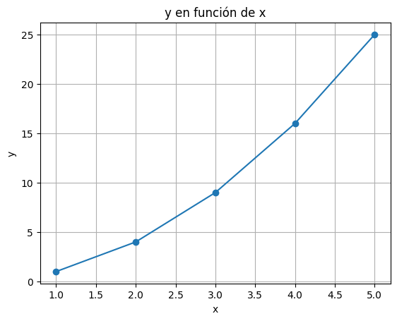

```python
x = [x for x in range(1, 6)]
y = [x_i**2 for x_i in x]

plt.plot(x, y, marker="o")
plt.title("y en función de x")
plt.xlabel("x")
plt.ylabel("y")
plt.grid(True)
plt.show()
```

## Pandas

Sirve para manipular y analizar datos usando `DataFrame`s. Por ejemplo, puede obtener la media aritmética de una columna.

```python
personas = {
    "Nombre": ["Ana", "Luis", "María"],
    "Edad": [25, 30, 22]
}

df = pd.DataFrame(personas)
print("Dataframe:")
print(df)
print("\nEdad promedio:", df["Edad"].mean())
```

```
Dataframe:
  Nombre  Edad
0    Ana    25
1   Luis    30
2  María    22

Edad promedio: 25.666666666666668
```

## Scipy

Optimización, integración, álgebra lineal y ortas herramientas científicas. El ejemplo encuentra el mínimo de `f(x)`, una función cuadrática.

```python
def f(x):
    return x**2 + 3 * x + 2
```

```python
# x0 es el punto inicial.
min_global = opt.minimize(f, x0=0)
print("Mínimo de f(x) =", min_global)
```

```
Mínimo de f(x) =   message: Optimization terminated successfully.
  success: True
   status: 0
      fun: -0.25
        x: [-1.500e+00]
      nit: 2
      jac: [ 0.000e+00]
 hess_inv: [[ 5.000e-01]]
     nfev: 6
     njev: 3
```

## Time

Permite cronometrar la ejecución de una sección de código.

```python
start_time = time.time()

for i in range(10**6):
    pass

end_time = time.time()

print(f"Ejecución tomó {end_time - start_time} segundos")
```

```
Ejecución tomó 0.13099288940429688 segundos
```

## YFinance

Descarga datos financieros desde Yahoo Finance. En este ejemplo, descarga los valores históricos de los últimos 5 días de AAPL.

```python
apple = yf.Ticker("AAPL")
aapl_history = apple.history(period="5d")
print("Datos históricos de AAPL")
print(aapl_history)
```

```
Datos históricos de AAPL
                                 Open        High         Low       Close  \
Date
2025-01-16 00:00:00-05:00  237.350006  238.009995  228.029999  228.259995
2025-01-17 00:00:00-05:00  232.119995  232.289993  228.479996  229.979996
2025-01-21 00:00:00-05:00  224.000000  224.419998  219.380005  222.639999
2025-01-22 00:00:00-05:00  219.789993  224.119995  219.789993  223.830002
2025-01-23 00:00:00-05:00  224.740005  227.029999  222.300003  223.660004

                             Volume  Dividends  Stock Splits
Date
2025-01-16 00:00:00-05:00  71759100        0.0           0.0
2025-01-17 00:00:00-05:00  68488300        0.0           0.0
2025-01-21 00:00:00-05:00  98070400        0.0           0.0
2025-01-22 00:00:00-05:00  64126500        0.0           0.0
2025-01-23 00:00:00-05:00  60178200        0.0           0.0
```

## Scikit-Learn

ML y procesamiento de datos. El ejemplo usa `StandardScaler` para escalar una matriz de datos.

```python
data = np.array([[1, 2, 3], [4, 5, 6], [7, 8, 9]])
scaler = StandardScaler()
scaled_data = scaler.fit_transform(data)
print("Datos originales:")
print(data)
print("\nDatos escalados:")
print(scaled_data)
```

```
Datos originales:
[[1 2 3]
 [4 5 6]
 [7 8 9]]

Datos escalados:
[[-1.22474487 -1.22474487 -1.22474487]
 [ 0.          0.          0.        ]
 [ 1.22474487  1.22474487  1.22474487]]
```